# Prosper

Prosper was founded in 2005 as the first peer-to-peer lending marketplace in the United States. Since then, Prosper has facilitated more than $14 billion in loans to more than 870,000 people.

Borrowers apply online for a fixed-rate, fixed-term loan between \$2000 and \$40000. Individuals and institutions can invest in the loans and earn attractive returns. Prosper handles all loan servicing on behalf of the matched borrowers and investors.

### What can we expect from prosper?

- The **estimated return** is assigned to the listing at the time it was created and is the difference between the Estimated Effective Yield and the Estimated Loss Rate.

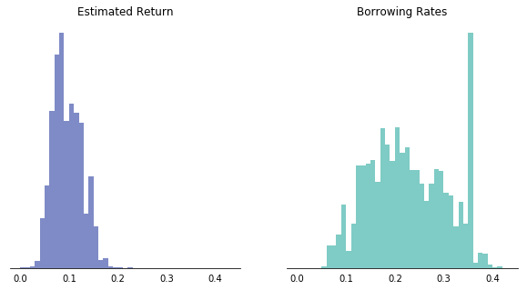

```python
fig = plt.figure(figsize = (10,5))
ax1 = fig.add_subplot(1,2,1)
ax2 = fig.add_subplot(1,2,2)

axes = [ax1,ax2]
positions=['right','left','top']
bin_edges1=np.arange(0,max(post_july["BorrowerAPR"].dropna())+0.01,0.01)
ax1.hist(post_july["EstimatedReturn"].dropna(), bins = bin_edges1, color = '#00198e', alpha =0.5);

for ax in axes:
    ax.tick_params(left = 'off', bottom = 'off')
    for pos in positions:
        ax.spines[pos].set_visible(False)
    ax.set_yticklabels('')

ax1.set_title("Estimated Return")
ax2.set_title('Borrowing Rates')

bin_edges2=np.arange(0,max(post_july["BorrowerAPR"])+0.01,0.01)
ax2.hist(post_july["BorrowerAPR"], bins=bin_edges2, color = '#00998c',alpha=0.5);
```

Here we see a disparity between the spread of borrowing rates and the spread of returns. As borrowing rates are determined by the riskiness of the investment, it is worthwhile noting the distribution of risk amongst the loans listed.

### Who Uses Prosper?

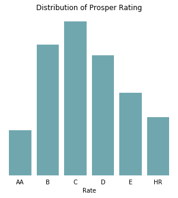

```python
bars= ['AA','B','C','D','E','HR']
f, ax = plt.subplots(figsize=(5,5))
#ax.bar(x = ticks,height=post_july.groupby("ProsperRating").size().reset_index(name='count')["count"], color='#00698c', alpha=0.5)
sns.countplot(data = post_july, x = "ProsperRating", color = '#00798c', order = bars, alpha = 0.6)
sns.despine(left = True, bottom=True)
ax.tick_params(left = 'off', bottom = 'off')
ax.set_yticklabels('')
ax.set_ylabel('')
ax.set_xlabel("Rate")
ax.set_title("Distribution of Prosper Rating");
```

Here we see that the distribution of risk follows something of a bell shaped curved. Some additional context could be provided by the fact that about 70% of the listings with reported income have stated that the earn between \$2500 - $8000 monthly. This suggests that prosper generally attracts middle class borrowers.

### What Categories are more likely to Default?

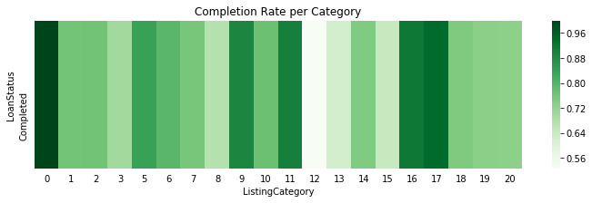

```python
denom = finished_loans.groupby(['ListingCategory']).size()
lcounts =  finished_loans.groupby(["ListingCategory","LoanStatus"]).size()
lprops = lcounts / denom
lprops = lprops.reset_index(name='count')
lprops = lprops.pivot_table(index='LoanStatus',columns='ListingCategory',values = 'count', fill_value = 0)
lprops.drop(["Chargedoff","Defaulted"],inplace=True)
fig, ax = plt.subplots(figsize=(12,3))
sns.heatmap(lprops, cmap="Greens")
ax.tick_params(left = 'off', bottom = 'off')
ax.set_title("Completion Rate per Category");
```

- 12: Green loans have the lowest Completion Rate but with 10/18 completions it is difficult to say whether the category is necessarily riskier than the others or whether it was just a new type by 2014.
- 16: Motorcylcle loans have a particularly high completion rate with 86/94

Overall, we can see that for any category loans are completed more than half the time.

### How does the length of time affect risk?

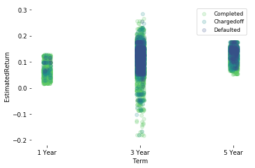

```python
g = sns.FacetGrid(data = post_july, hue = 'LoanStatus', hue_order = ['Completed','Chargedoff','Defaulted'], palette="viridis_r",size = 4 , aspect = 1.5)
g.map(sns.regplot,"Term", "EstimatedReturn", fit_reg = False, x_jitter=True, scatter_kws={'alpha':0.2});
plt.legend(loc=1, fontsize = 9)
g.set(xticks=np.arange(12,84,24),xticklabels=["1 Year", "3 Year", "5 Year" ], alpha=0.0000)
sns.despine(left=True,bottom=True)
```

- 1 year loans have the lowest history of defaulting with reeasonable returns peaking at about 10%
- 3 year loans have the widest range of expected returns, with more extreme rates seeming to have lower defaults historically.
- 5 year loans have higher returns on average than 1 year but at a much higher risk of default historically

### How does Risk Vary with Return?

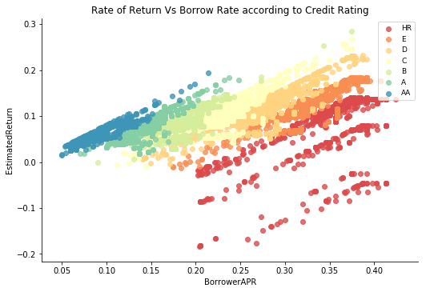

```python
g = sns.FacetGrid(data = post_july, hue = 'ProsperRating', hue_order = ['HR','E','D','C','B','A','AA'], size = 5, aspect = 1.5, palette="Spectral")
g.map(sns.regplot,"BorrowerAPR", "EstimatedReturn", fit_reg = False);
plt.legend(loc=1, fontsize = 9)
plt.title("Rate of Return Vs Borrow Rate according to Credit Rating");
```

Since Borrowing rates are determined according to the credit rating assigned, we can see here how the risk is dispersed amongst the expected returns. In particular, it would appear as though an investor will have to tread very lightly with Borrowing APR's over 20% as their is significantly larger chance of losing significant portions of their investment.